# Wypadki samochodowe - Paweł Matys

# https://www.kaggle.com/prasannakm/car-crash-dataset

## Statystyki opisowe

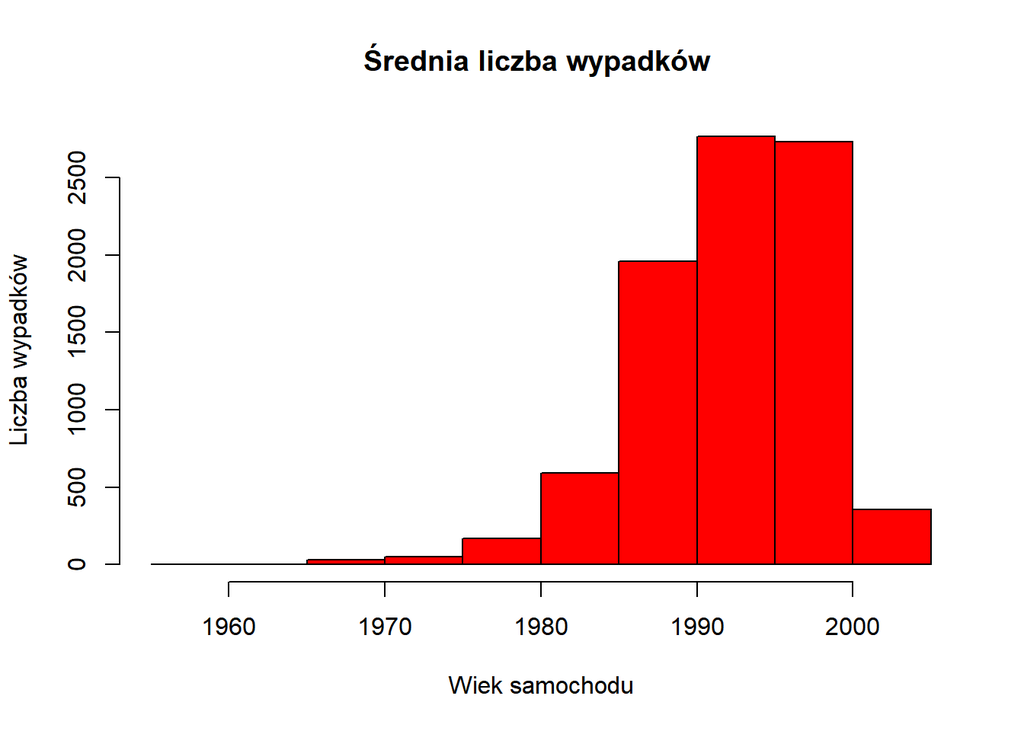

```r
CarCrash <- read.csv("test-new.csv")
CarCrash <- na.omit(CarCrash)
 wiek <- CarCrash$yearVeh
 smierc <- CarCrash$dead
 predkosc <- CarCrash$dvcat
 pasy <- CarCrash$seatbelt
 poduszka <- CarCrash$airbag
 wiekKierowcy <- CarCrash$ageOFocc
 plec <- CarCrash$sex

hist(wiek, col="red",xlab="Wiek samochodu",ylab="Liczba wypadków",main = "Średnia liczba wypadków ")
```

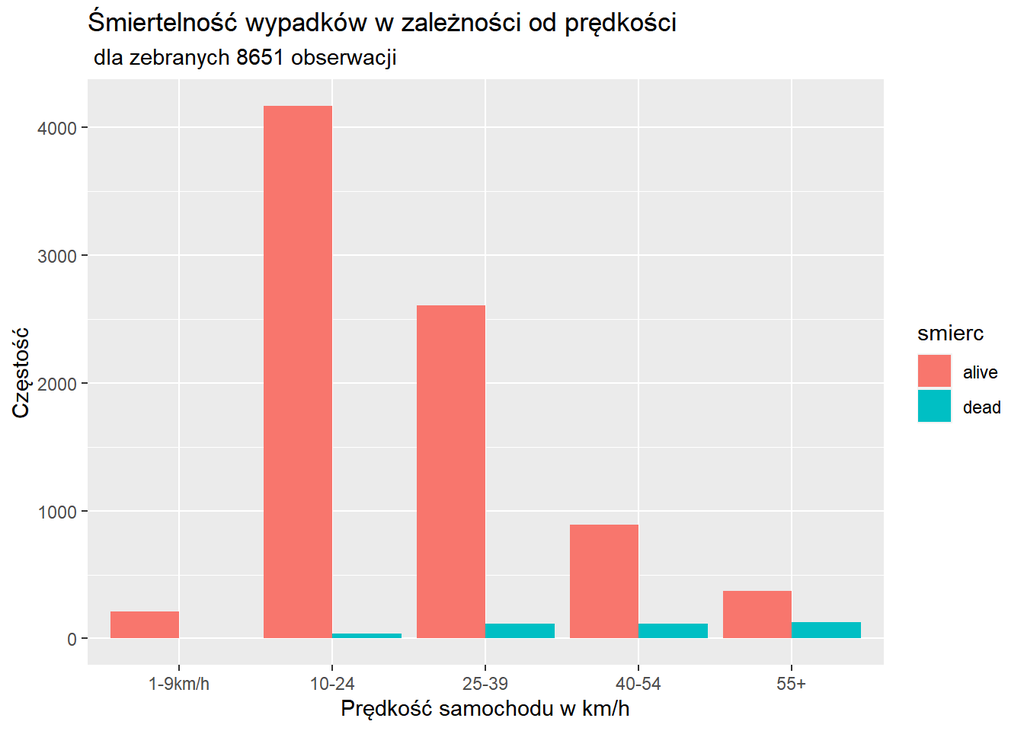

```r
ggplot(data = CarCrash, aes(x = predkosc, fill = smierc)) + geom_bar(position= 'dodge') + labs(title="Śmiertelność wypadków w zależności od prędkości", subtitle = " dla zebranych 8651 obserwacji" , x= "Prędkość samochodu w km/h", y = "Częstość")
```

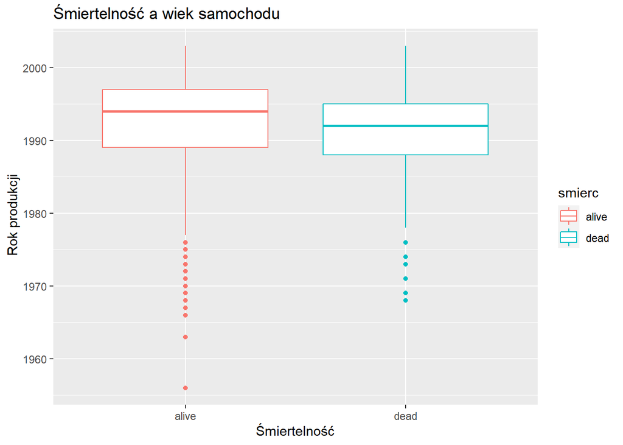

```r
qplot(x = smierc, y=wiek, color = smierc, geom = 'boxplot', data = CarCrash, main = "Śmiertelność a wiek samochodu", xlab = "Śmiertelność", ylab = " Rok produkcji")
```

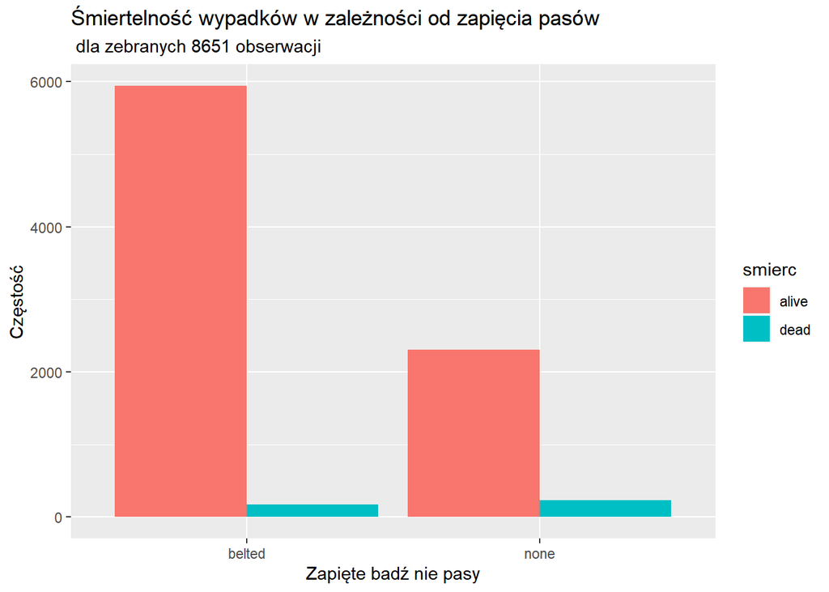

```r
ggplot(data = CarCrash, aes(x = pasy, fill = smierc)) + geom_bar(position= 'dodge') + labs(title="Śmiertelność wypadków w zależności od zapięcia pasów", subtitle = " dla zebranych 8651 obserwacji" , x= "Zapięte badź nie pasy", y = "Częstość")
```

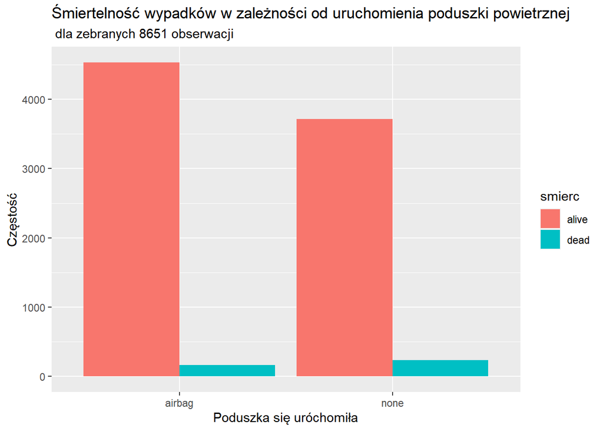

```r
ggplot(data = CarCrash, aes(x = poduszka, fill = smierc)) + geom_bar(position= 'dodge') + labs(title="Śmiertelność wypadków w zależności od uruchomienia poduszki powietrznej", subtitle = " dla zebranych 8651 obserwacji" , x= "Poduszka się uróchomiła", y = "Częstość")
```

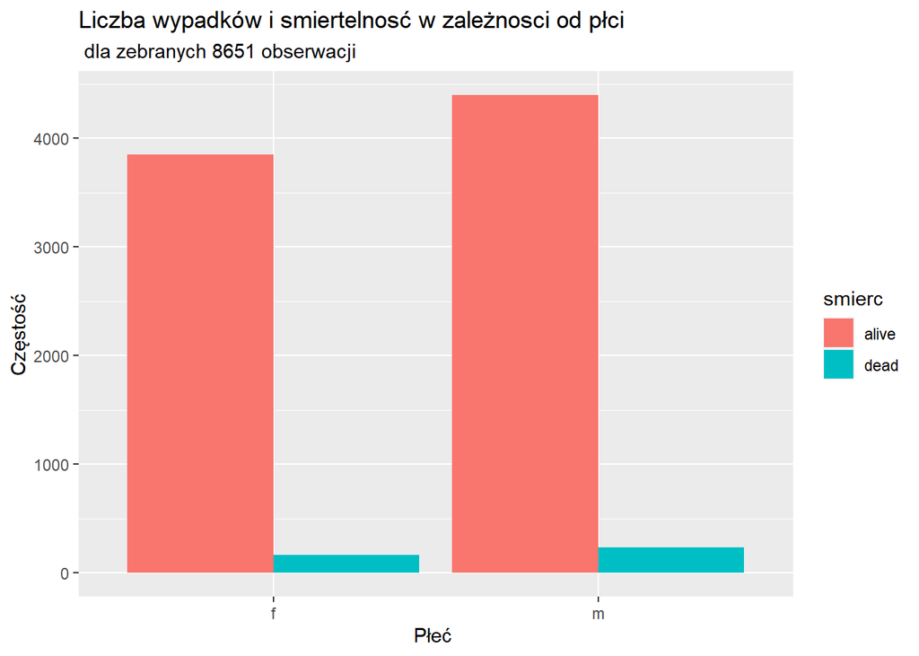

```r
 ggplot(data = CarCrash, aes(x = CarCrash$sex, fill = smierc)) + geom_bar(position= 'dodge') + labs(title="Liczba wypadków i smiertelnosć w zależnosci od płci", subtitle = " dla zebranych 8651 obserwacji" , x= "Płeć ", y = "Częstość")
```

# Hipoteza 1

h0: Wiek samochodów w grupie osób, które zgineły w wypadkach jest taki sam lub niższy jak w grupie osób, które przeżyły wypadek.

hA: Wiek samochodów w grupie osób, które zginęły w wypadkach jest wyższy (rocznik jest starszy), niż w grupie osób, które przeżyły wypadek.

```r
CarCrashDeath <- filter(CarCrash, smierc == "dead")
CarCrashAlive <- filter(CarCrash, smierc == "alive")
t.test(CarCrashDeath$yearVeh, CarCrashAlive$yearVeh, alternative = "less" )
```

```
##
##  Welch Two Sample t-test
##
## data:  CarCrashDeath$yearVeh and CarCrashAlive$yearVeh
## t = -5.4378, df = 438.49, p-value = 4.488e-08
## alternative hypothesis: true difference in means is less than 0
## 95 percent confidence interval:
##       -Inf -1.137602
## sample estimates:
## mean of x mean of y
##  1991.169  1992.801
```

W celu zweryfikowania hipotezy użyłem tetstu t Studenta z poprawką Welscha (dzięki tej poprawce wariancja w grupach nie musi być równa). Grupy nie są równoliczne, dlatego postanowiłem użyć dodatkowo testu nieparametrycznego, który w tej sytuacji wydaje się lepszy. Liczba obserwacji w grupach jest w stosunku 20:1. Poniżej test sumy rank Wilcoxona.

```r
wilcox.test(CarCrashDeath$yearVeh, CarCrashAlive$yearVeh, alternative = "less" )
```

```
##
##  Wilcoxon rank sum test with continuity correction
##
## data:  CarCrashDeath$yearVeh and CarCrashAlive$yearVeh
## W = 1382306, p-value = 5.263e-09
## alternative hypothesis: true location shift is less than 0
```

W oparciu o wynik testu zasadne jest odrzucenie hipotezy zerowej i przyjęcie hipotezy alternatywnej. Wiek samochodów w grupie osób, które zginęły w wypadkach jest wyższy (rocznik jest starszy), niż w grupie osób, które przeżyły wypadek.

#Hipoteza 2 h0: Kobiety tak samo często lub częściej umierają w wypadkach samochodowych niż mężczyźni. (gdy już dojdzie do wypadku)

hA: Kobiety rzadziej umierają w wypadkach samochodowych niż mężczyźni. (gdy już dojdzie do wypadku)

```r
CarCrashDeathK <- filter(CarCrash, plec == 'f', smierc=="dead")
CarCrashDeathM <- filter(CarCrash, plec == 'm', smierc == "dead")

ulamekSmiertelnosci <- 403/8651
liczbaKobiet <- count(CarCrash, plec == 'f') #liczę liczbe mezczyzn i kobiet
zaobserwowane = c(169,234)
oczekiwane = c(4020*403/8651,4631*403/8651)

# obliczam statystykę testową chi kwadrat
chi_kw = sum((zaobserwowane - oczekiwane)**2/oczekiwane)

# za pomocą dystrybuanty  wyznaczam
# prawdopodobieństwo uzyskania takiego
# lub bardziej skrajnego wyniku
pchisq(chi_kw, 1, lower.tail = FALSE)
```

```
## [1] 0.06806195
```

W oparciu o wynik testu zasadne jest przyjęcie hipotezy zerowej (przyejliśmy afle = 0,05). Kobiety tak samo często lub częściej umierają w wypadkach samochodowych niż mężczyźni. (gdy już dojdzie do wypadku). Wynik jest jednak na poziomie tendencji statystycznej p = 0.07.

# Hipoteza 3

h0: Wiek użytkownika samochodu nie jest skoroelowany z wiekiem samochodu lub jest z nim skorelowany ujemnie

hA: Wiek użytkownika samochodu jest dodatnio skorelowany z wiekiem samochodu.

```r
cor.test(x =wiek, y = wiekKierowcy)
```

```
##
##  Pearson's product-moment correlation
##
## data:  wiek and wiekKierowcy
## t = 0.94965, df = 8649, p-value = 0.3423
## alternative hypothesis: true correlation is not equal to 0
## 95 percent confidence interval:
##  -0.01086454  0.03127703
## sample estimates:
##        cor
## 0.01021078
```

W oparciu o wynik testu na istotność współczynika korelacji r - Pearsona przyjmujemy h0. Wynik testu nie okazał się istotny statystycznie.